# Lab 6

Author

Isabella Villanueva

# Lab 6: Text Mining

#### Loading in the `mt_samples` dataset.

```r
library(dplyr)
library(data.table)
library(ggplot2)
library(tidytext)
```

```r
library(readr)
library(dplyr)
mt_samples <- read_csv("https://raw.githubusercontent.com/USCbiostats/data-science-data/master/00_mtsamples/mtsamples.csv")
```

```
──────────────────────────────────────────────────────── Delimiter: "," chr
(5): description, medical_specialty, sample_name, transcription, keywords dbl
(1): ...1
```

```r
mt_samples <- mt_samples %>%
  select(description, medical_specialty, transcription)

head(mt_samples)
```

```
# A tibble: 6 × 3
  description                                    medical_specialty transcription
  <chr>                                          <chr>             <chr>
1 A 23-year-old white female presents with comp… Allergy / Immuno… "SUBJECTIVE:…
2 Consult for laparoscopic gastric bypass.       Bariatrics        "PAST MEDICA…
3 Consult for laparoscopic gastric bypass.       Bariatrics        "HISTORY OF …
4 2-D M-Mode. Doppler.                           Cardiovascular /… "2-D M-MODE:…
5 2-D Echocardiogram                             Cardiovascular /… "1.  The lef…
6 Morbid obesity.  Laparoscopic antecolic anteg… Bariatrics        "PREOPERATIV…
```

## Question 1. What specialities do we have?

```r
colnames(mt_samples)
```

```
[1] "description"       "medical_specialty" "transcription"
```

```r
library(dplyr)
mt_samples <- mt_samples %>%
  rename(desc = description, #Renaming variables for convenience
         med_spec = medical_specialty,
         tran = transcription)
```

```r
mt_samples %>%
  count(desc, sort = TRUE)
```

```
# A tibble: 2,348 × 2
   desc                                                                        n
   <chr>                                                                   <int>
 1 An example/template for a routine normal male physical exam.               12
 2 Common description of colonoscopy                                          10
 3 Sample normal ear, nose, mouth, and throat exam.                            8
 4 Sample progress note - Gen Med.                                             8
 5 An example/template for a routine normal female physical exam.              6
 6 Common description of EGD.                                                  6
 7 Normal review of systems template.  Negative weakness, negative fatigu…     6
 8 Occupational medicine consult with questions-answers and records revie…     6
 9 <NA>                                                                        6
10 Lumbar discogram L2-3, L3-4, L4-5, and L5-S1.  Low back pain.               5
# ℹ 2,338 more rows
```

```r
mt_samples %>%
  count(med_spec, sort = TRUE)
```

```
# A tibble: 40 × 2
   med_spec                          n
   <chr>                         <int>
 1 Surgery                        1103
 2 Consult - History and Phy.      516
 3 Cardiovascular / Pulmonary      372
 4 Orthopedic                      355
 5 Radiology                       273
 6 General Medicine                259
 7 Gastroenterology                230
 8 Neurology                       223
 9 SOAP / Chart / Progress Notes   166
10 Obstetrics / Gynecology         160
# ℹ 30 more rows
```

```r
mt_samples %>%
  count(tran, sort = TRUE)
```

```
# A tibble: 2,358 × 2
   tran                                                                        n
   <chr>                                                                   <int>
 1  <NA>                                                                      33
 2 "PREOPERATIVE DIAGNOSIS: , Low back pain.,POSTOPERATIVE DIAGNOSIS: , L…     5
 3 "ADMISSION DIAGNOSES:,1.  Seizure.,2.  Hypoglycemia.,3.  Anemia.,4.  H…     4
 4 "CHIEF COMPLAINT:  ,Blood in toilet.,HISTORY: , Ms. ABC is a 77-year-o…     4
 5 "CHIEF COMPLAINT: , Blood in urine.,HISTORY OF PRESENT ILLNESS:  ,This…     4
 6 "CHIEF COMPLAINT: , Burn, right arm.,HISTORY OF PRESENT ILLNESS: , Thi…     4
 7 "CHIEF COMPLAINT: , Jaw pain.,HISTORY OF PRESENT ILLNESS:  ,This is a …     4
 8 "CHIEF COMPLAINT: , Newly diagnosed high-risk acute lymphoblastic leuk…     4
 9 "CHIEF COMPLAINT:,"                                                         4
10 "CHIEF COMPLAINT:,  Abdominal pain.,HISTORY OF PRESENT ILLNESS:,  The …     4
# ℹ 2,348 more rows
```

### How many different categories do we have? Are these categories related? overlapping? evenly distributed?

From the `count` function, we can analyze the `mt_samples` dataset’s 3 different variables.

Within the `medical_speciality` variable (renamed as `med_spec`), 40 unique categories were counted while this variable included an `n` column, which counts the number of overlapping observations with the same categorization (i.e. 1103 observations were categorized as “Surgery” and 516 observations were labeled “Consult- History and Phy.”).

Not all of these variables have evenly distributed categories, as `medical_speciality` does have higher proportions of its variable within one categories than another.

## Question 2.

#### - Tokenize the words in the transcription column

```r
library(tidytext)
mt_samples |>
  unnest_tokens(token, tran)
```

```
# A tibble: 2,403,596 × 3
   desc                                                           med_spec token
   <chr>                                                          <chr>    <chr>
 1 A 23-year-old white female presents with complaint of allergi… Allergy… subj…
 2 A 23-year-old white female presents with complaint of allergi… Allergy… this
 3 A 23-year-old white female presents with complaint of allergi… Allergy… 23
 4 A 23-year-old white female presents with complaint of allergi… Allergy… year
 5 A 23-year-old white female presents with complaint of allergi… Allergy… old
 6 A 23-year-old white female presents with complaint of allergi… Allergy… white
 7 A 23-year-old white female presents with complaint of allergi… Allergy… fema…
 8 A 23-year-old white female presents with complaint of allergi… Allergy… pres…
 9 A 23-year-old white female presents with complaint of allergi… Allergy… with
10 A 23-year-old white female presents with complaint of allergi… Allergy… comp…
# ℹ 2,403,586 more rows
```

#### - Count the number of times each token appears

```r
library(tidytext)
mt_samples |>
  unnest_tokens(token, tran) |>
  count(token, sort = TRUE)
```

```
# A tibble: 23,647 × 2
   token        n
   <chr>    <int>
 1 the     149888
 2 and      82779
 3 was      71765
 4 of       59205
 5 to       50632
 6 a        42810
 7 with     35815
 8 in       32807
 9 is       26378
10 patient  22065
# ℹ 23,637 more rows
```

#### - Visualize the top 20 most frequent words

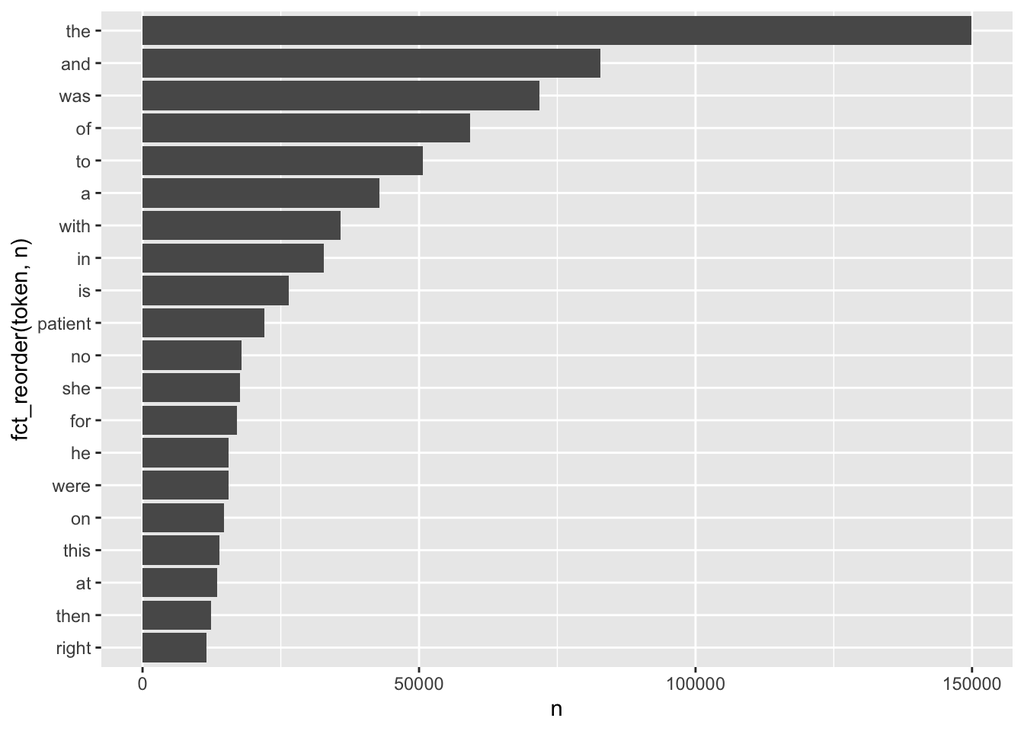

```r
library(tidytext)
library(dplyr)
library(ggplot2)
library(forcats)
mt_samples |>
  unnest_tokens(token, tran) |>
  count(token, sort = TRUE) |>
  top_n(20,n)|>
  ggplot(aes(n, fct_reorder(token, n))) +
  geom_col()
```

### Explain what we see from this result. Does it makes sense? What insights (if any) do we get?

From tokenizing the words of the `transcription` column, we were able to see the number of times 23,647 words appeared in this column. With the `top_n` function, we can visualize the 20 most common words in this column’s data, and how many times each word appeared. The word “the” was used 149,888 times, followed by the word “and” at half its number of observed times!

## Question 3.

#### - Redo visualization but remove `stop_words` before

#### - Bonus points if you remove numbers as well

```r
library(tidytext)
library(dplyr)
library(ggplot2)
library(forcats)
library(stringr)
stop_words
```

```
# A tibble: 1,149 × 2
   word        lexicon
   <chr>       <chr>
 1 a           SMART
 2 a's         SMART
 3 able        SMART
 4 about       SMART
 5 above       SMART
 6 according   SMART
 7 accordingly SMART
 8 across      SMART
 9 actually    SMART
10 after       SMART
# ℹ 1,139 more rows
```

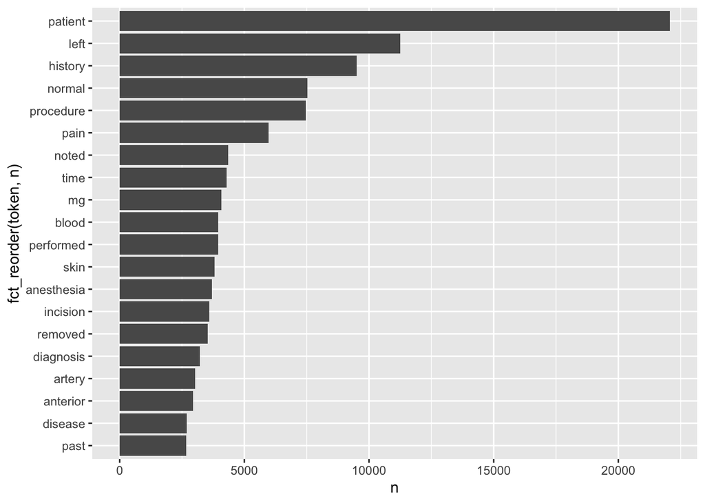

```r
mt_samples |>
  unnest_tokens(token, tran) |>
  anti_join(stop_words, by = c("token" = "word")) |> #Removal of stop_words
  filter(!str_detect(token, "^\\d+$")) |> #Removal of numbers
  count(token, sort = TRUE) |>
  top_n(20,n)|>
  ggplot(aes(n, fct_reorder(token, n))) +
  geom_col()
```

### What do we see know that we have removed stop words? Does it give us a better idea of what the text is about?

Now that we have removed the `stop_words`, the previously high ranking word “the” has been dethroned by the word “patient”, which allows more insight into the data input from the transcription column in our dataset. Seeing this visualization with the noise eliminated from the filler words or stop words, we can notice more medical terminology in these top 20 most used words graphic.

## Question 4.

#### Repeat question 2, but this time tokenize into bi-grams.

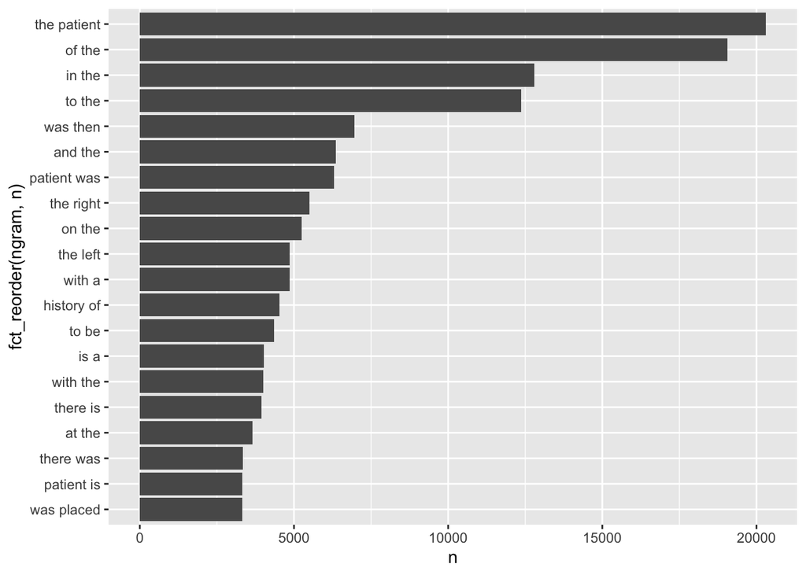

```r
library(tidytext)
library(dplyr)
library(ggplot2)
library(forcats)
mt_samples |>
  unnest_ngrams(ngram,tran, n =2) |> #Instead of creating words into tokens, making two word phrases = bigrams
  count(ngram, sort = TRUE) |>
  top_n(20,n)|>
  ggplot(aes(n, fct_reorder(ngram, n))) +
  geom_col()
```

### How does the result change if you look at tri-grams?

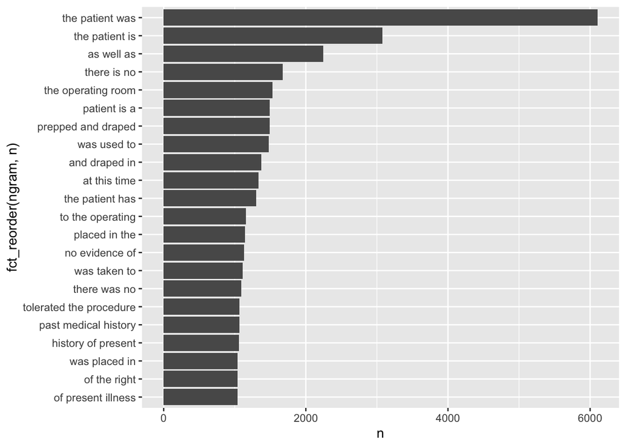

```r
library(tidytext)
library(dplyr)
library(ggplot2)
library(forcats)
mt_samples |>
  unnest_ngrams(ngram,tran, n =3) |> #Instead of creating words into tokens, making two word phrases = trigrams
  count(ngram, sort = TRUE) |>
  top_n(20,n)|>
  ggplot(aes(n, fct_reorder(ngram, n))) +
  geom_col()
```

#### Bi-grams vs. Tri-grams

- “the patient was”,
- “the patient is”, and
- “as well as”.

The bi-grams graph had the same token at its most used, “patient”, but with the specification of two words to three, more information can be collected on the mode of phrases compared to the bi-grams’ graphic showing normally used phrases like:

- “of the”,
- “in the”, and
- “to the”.

The bi-grams result has been readjusted with the tri-grams output, where it bears similar results to before and after the removal of stop words.

### Question 5. Using the results you got from Question 4, pick a word and count the words that appears after and before it.

#### Chosen Word: “patient”

#### Words that appear after “patient”

```r
library(tidytext)
library(tidyr)
mt_samples |>
  unnest_ngrams(ngram, tran, n = 2) |>
  separate(ngram, into = c("word1", "word2"), sep = " ") |>
  select(word1, word2) |>
  filter(word1 == "patient") |>
  count(word2, sort = TRUE) #words that appear after "patient"
```

```
# A tibble: 588 × 2
   word2         n
   <chr>     <int>
 1 was        6293
 2 is         3332
 3 has        1417
 4 tolerated   994
 5 had         888
 6 will        616
 7 denies      552
 8 and         377
 9 states      363
10 does        334
# ℹ 578 more rows
```

#### Words that appear before “patient”

```r
library(tidytext)
mt_samples |>
  unnest_ngrams(ngram, tran, n = 2) |>
  separate(ngram, into = c("word1", "word2"), sep = " ") |>
  select(word1, word2) |>
  filter(word2 == "patient") |>
  count(word1, sort = TRUE)
```

```
# A tibble: 269 × 2
   word1         n
   <chr>     <int>
 1 the       20307
 2 this        470
 3 history     101
 4 a            67
 5 and          47
 6 procedure    32
 7 female       26
 8 with         25
 9 use          24
10 old          23
# ℹ 259 more rows
```

### Question 6.

#### Which words are most used in each of the specialties? How about the most 5 used words?

##### You can use `group_by`and `top_n` from dplyr to have the calculations be done within each specialty. Remember to remove stop words.

##### Below shows the top 5 most used words across each of the specialities.

```r
library(tidytext)
library(dplyr)
library(forcats)
library(stringr)
library(ggplot2)
med_spec_mostused <- mt_samples |>
  unnest_tokens(token, tran) |>
  anti_join(stop_words, by = c("token" = "word")) |>
  filter(!str_detect(token, "^\\d+$")) |>
  group_by(med_spec) |>
  count(token, sort = TRUE)|>
  top_n(5, n)|>
  slice_max(order_by = n, n = 5)

print(med_spec_mostused)
```

```
# A tibble: 210 × 3
# Groups:   med_spec [40]
   med_spec             token         n
   <chr>                <chr>     <int>
 1 Allergy / Immunology history      38
 2 Allergy / Immunology noted        23
 3 Allergy / Immunology patient      22
 4 Allergy / Immunology allergies    21
 5 Allergy / Immunology nasal        13
 6 Allergy / Immunology past         13
 7 Autopsy              left         83
 8 Autopsy              inch         59
 9 Autopsy              neck         55
10 Autopsy              anterior     47
# ℹ 200 more rows
```